# Oracle Operations POC using UCI Bank Marketing Dataset

# Flow of Oracle POC

1. Data visualisations on input dataset
2. Data cleaning
3. Categorical encoding
4. Data visualisations on cleaned dataset
5. Clustering & feature engineering using k-means clustering
6. Final dataset
7. Train test split and SMOTE
8. Logistic regression models with stratified 10-fold cross validation(cv)
9. CART models with 10-fold cv
10. XGBoost model with stratified 10-fold cv
11. XGBoost feature importance
12. Boruta feature selection
13. Optimised XGBoost using Boruta features with stratified 10-fold cv
14. XGBoost for Boruta data & HR data with stratified 10-fold cv
15. XGBoost for Boruta data & Investment data with stratified 10-fold cv
16. XGBoost for Boruta data & HR & Investment data with stratified 10-fold cv
17. Optimised XGBoost from (17) with hyperparameter tuning

# Import libraries

```r
# data table
library(data.table)
# data visualisation
library(gmodels)
library(corrplot)
library(caTools)
library(ggplot2)
library(reshape2)
library(caTools)
library(ggridges)
library(scales)
library(ggmosaic)
library(cluster)
library(gridExtra)
library(factoextra)
# data cleaning
library(mltools)
library(DMwR)
library(dplyr)
# feature selection
library(Boruta)
library(rFerns)
# predictive modelling
library(rpart)
library(rpart.plot)
library(xgboost)
library(caret)
library(cluster)
```

# Our Problem

Reducing labour costs through the automation of operational processes.

# Read csv data

```r
bankData <-fread("C:/Users/qingy/OneDrive/Documents/BC2406 Analytics I/Project/bank-full.csv", stringsAsFactors = TRUE)
#bankData <-fread("bank-full.csv", stringsAsFactors = TRUE)
head(bankData)
```

| age | job | marital | education | default | balance | housing | loan | contact | day | month | duration | campaign | pdays | previous | poutcome | y |
| --- | --- | --- | --- | --- | --- | --- | --- | --- | --- | --- | --- | --- | --- | --- | --- | --- |
| 58 | management | married | tertiary | no | 2143 | yes | no | unknown | 5 | may | 261 | 1 | -1 | 0 | unknown | no |
| 44 | technician | single | secondary | no | 29 | yes | no | unknown | 5 | may | 151 | 1 | -1 | 0 | unknown | no |
| 33 | entrepreneur | married | secondary | no | 2 | yes | yes | unknown | 5 | may | 76 | 1 | -1 | 0 | unknown | no |
| 47 | blue-collar | married | unknown | no | 1506 | yes | no | unknown | 5 | may | 92 | 1 | -1 | 0 | unknown | no |
| 33 | unknown | single | unknown | no | 1 | no | no | unknown | 5 | may | 198 | 1 | -1 | 0 | unknown | no |
| 35 | management | married | tertiary | no | 231 | yes | no | unknown | 5 | may | 139 | 1 | -1 | 0 | unknown | no |

# Exploratory Data Analysis

### Size of dataset

```r
dim(bankData)
```

```
[1] 45211    17
```

### Column names of dataset

```r
names(bankData)
```

```
 [1] "age"       "job"       "marital"   "education" "default"   "balance"   "housing"   "loan"      "contact"
[10] "day"       "month"     "duration"  "campaign"  "pdays"     "previous"  "poutcome"  "y"
```

### Statistical Summary of dataset

```r
summary(bankData)
```

```
      age                 job           marital          education     default        balance       housing
 Min.   :18.00   blue-collar:9732   divorced: 5207   primary  : 6851   no :44396   Min.   : -8019   no :20081
 1st Qu.:33.00   management :9458   married :27214   secondary:23202   yes:  815   1st Qu.:    72   yes:25130
 Median :39.00   technician :7597   single  :12790   tertiary :13301               Median :   448
 Mean   :40.94   admin.     :5171                    unknown  : 1857               Mean   :  1362
 3rd Qu.:48.00   services   :4154                                                  3rd Qu.:  1428
 Max.   :95.00   retired    :2264                                                  Max.   :102127
                 (Other)    :6835
  loan            contact           day            month          duration         campaign
 no :37967   cellular :29285   Min.   : 1.00   may    :13766   Min.   :   0.0   Min.   : 1.000
 yes: 7244   telephone: 2906   1st Qu.: 8.00   jul    : 6895   1st Qu.: 103.0   1st Qu.: 1.000
             unknown  :13020   Median :16.00   aug    : 6247   Median : 180.0   Median : 2.000
                               Mean   :15.81   jun    : 5341   Mean   : 258.2   Mean   : 2.764
                               3rd Qu.:21.00   nov    : 3970   3rd Qu.: 319.0   3rd Qu.: 3.000
                               Max.   :31.00   apr    : 2932   Max.   :4918.0   Max.   :63.000
                                               (Other): 6060
     pdays          previous           poutcome       y
 Min.   : -1.0   Min.   :  0.0000   failure: 4901   no :39922
 1st Qu.: -1.0   1st Qu.:  0.0000   other  : 1840   yes: 5289
 Median : -1.0   Median :  0.0000   success: 1511
 Mean   : 40.2   Mean   :  0.5803   unknown:36959
 3rd Qu.: -1.0   3rd Qu.:  0.0000
 Max.   :871.0   Max.   :275.0000
```

### Check for null values

```r
sum(is.na(bankData))    ## no NA in dataset
```

```
[1] 0
```

### Rename output variable, y, to response for greater clarity in analysis

```r
# Rename column y to response
names(bankData)[names(bankData) == "y"] <- "response"
```

### Response - The clients subscribed a term deposit? (binary: ‘yes’, ‘no’)

```r
CrossTable(bankData$response)
```

```
   Cell Contents
|-------------------------|
|                       N |
|         N / Table Total |
|-------------------------|


Total Observations in Table:  45211


          |        no |       yes |
          |-----------|-----------|
          |     39922 |      5289 |
          |     0.883 |     0.117 |
          |-----------|-----------|
```

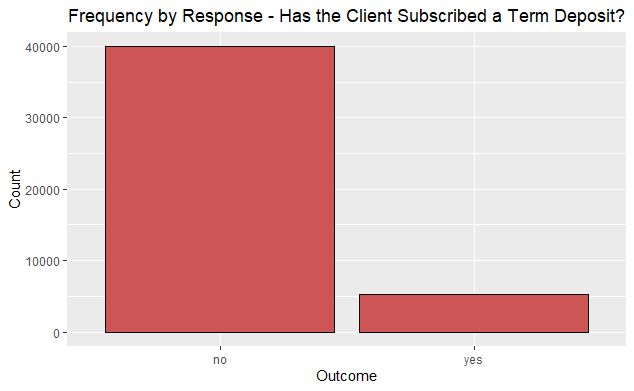

```r
ggplot(bankData, aes(x = response)) +
  geom_bar(fill = "indianred3", colour="black") +
  labs(x = "Outcome",
       y = "Count",
       title = "Frequency by Response - Has the Client Subscribed a Term Deposit?") +
  theme(plot.title = element_text(hjust = 0.5))
```

## Data Visualization:

### Univariate Numeric Analysis

```r
bankNum = bankData[, lapply(bankData, is.numeric) == TRUE, with = FALSE, ]
head(bankNum)
```

| age | balance | day | duration | campaign | pdays | previous |
| --- | --- | --- | --- | --- | --- | --- |
| 58 | 2143 | 5 | 261 | 1 | -1 | 0 |
| 44 | 29 | 5 | 151 | 1 | -1 | 0 |
| 33 | 2 | 5 | 76 | 1 | -1 | 0 |
| 47 | 1506 | 5 | 92 | 1 | -1 | 0 |
| 33 | 1 | 5 | 198 | 1 | -1 | 0 |
| 35 | 231 | 5 | 139 | 1 | -1 | 0 |

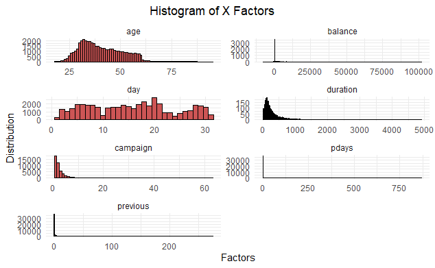

```r
ggplot(melt(bankNum), aes(x = value)) +
    facet_wrap(~ variable, scales = "free", ncol = 2) +
    geom_histogram(binwidth = 1, fill = "indianred3", colour="black")+
    theme_minimal()+
    labs(x = "Factors", y = "Distribution", title = "Histogram of X Factors") +
    theme(plot.title = element_text(hjust = 0.4))
```

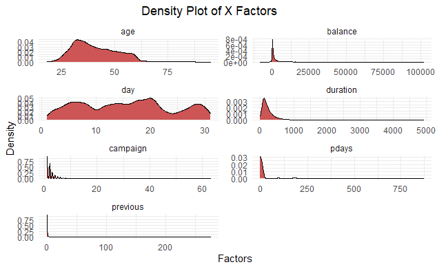

```r
# Create a kernel density plot of age
ggplot(melt(bankNum), aes(x = value)) +
  facet_wrap(~ variable, scales = "free", ncol = 2) +
  geom_density(fill = "indianred3")+
  theme_minimal()+
  labs(x = "Factors", y = "Density", title = "Density Plot of X Factors") +
  theme(plot.title = element_text(hjust = 0.4))
```

### Univariate Categorical Analysis

```r
bankCat = bankData[, lapply(bankData, is.factor) == TRUE, with = FALSE, ]
head(bankCat)
```

| job | marital | education | default | housing | loan | contact | month | poutcome | response |
| --- | --- | --- | --- | --- | --- | --- | --- | --- | --- |
| management | married | tertiary | no | yes | no | unknown | may | unknown | no |
| technician | single | secondary | no | yes | no | unknown | may | unknown | no |
| entrepreneur | married | secondary | no | yes | yes | unknown | may | unknown | no |
| blue-collar | married | unknown | no | yes | no | unknown | may | unknown | no |
| unknown | single | unknown | no | no | no | unknown | may | unknown | no |
| management | married | tertiary | no | yes | no | unknown | may | unknown | no |

```
attributes are not identical across measure variables; they will be dropped
```

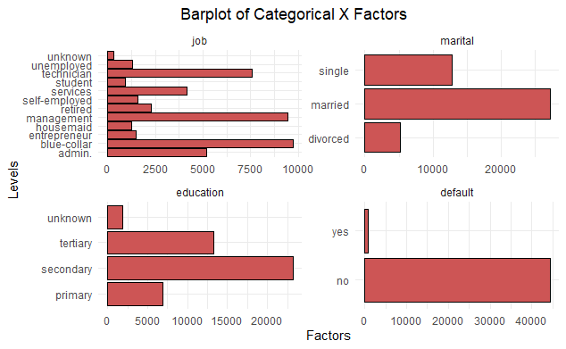

```r
bankCat1= bankCat[, c("job", "marital", "education","default", "response")]
ggplot(melt(bankCat1, id.vars="response"), aes(y = value)) +
  facet_wrap(~ variable, scales = "free", ncol=2) +
  geom_bar(fill = "indianred3", color="black")+
  theme_minimal()+
  labs(x = "Factors", y = "Levels", title = "Barplot of Categorical X Factors") +
  theme(plot.title = element_text(hjust = 0.35))
```

```
attributes are not identical across measure variables; they will be dropped
```

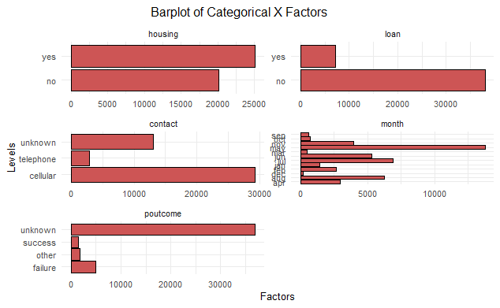

```r
bankCat2= bankCat[, c("housing","loan","contact","month","poutcome", "response")]
ggplot(melt(bankCat2, id.vars="response"), aes(y = value)) +
  facet_wrap(~ variable, scales = "free", ncol=2) +
  geom_bar(fill = "indianred3",
           color="black")+
  theme_minimal()+
  theme(text = element_text(size=10))+
  labs(x = "Factors", y = "Levels", title = "Barplot of Categorical X Factors") +
  theme(plot.title = element_text(hjust = 0.35))
```

### Bivariate Analysis

```r
bankNum1 = bankNum[, response := bankData$response]
```

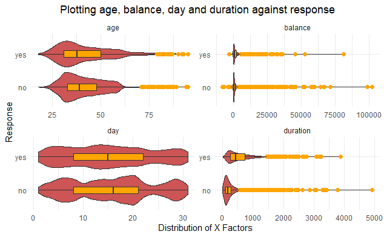

```r
# plot the distribution using violin and boxplots
bankNum2 = bankNum1[,c("age", "balance", "day", "duration", "response")]
ggplot(melt(bankNum2, id.vars="response"),
       aes(x = value,
           y = response)) +
  facet_wrap(~ variable, scales = "free", ncol=2) +
  geom_violin(fill = "indianred3") +
  geom_boxplot(width = .2,
               fill = "orange",
               outlier.color = "orange",
               outlier.size = 2)+
  theme_minimal()+
  labs(x = "Distribution of X Factors", y = "Response", title = "Plotting age, balance, day and duration against response") +
  theme(plot.title = element_text(hjust = 0.4))
```

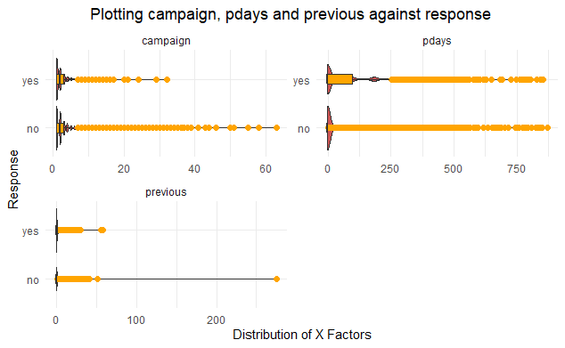

```r
# plot the distribution using violin and boxplots
bankNum3 = bankNum1[,c("campaign", "pdays", "previous", "response")]
ggplot(melt(bankNum3, id.vars="response"),
       aes(x = value,
           y = response)) +
  facet_wrap(~ variable, scales = "free", ncol=2) +
  geom_violin(fill = "indianred3") +
  geom_boxplot(width = .2,
               fill = "orange",
               outlier.color = "orange",
               outlier.size = 2)+
  theme_minimal()+
  labs(x = "Distribution of X Factors", y = "Response", title = "Plotting campaign, pdays and previous against response") +
  theme(plot.title = element_text(hjust = 0.4))
```

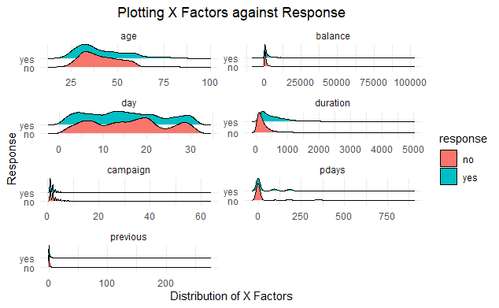

```r
ggplot(melt(bankNum1, id.vars="response"),
       aes(x = value,
           y = response,
           fill = response)) +
  facet_wrap(~ variable, scales = "free", ncol=2) +
  geom_density_ridges() +
  theme_ridges()+
  theme_minimal()+
  labs(x = "Distribution of X Factors", y = "Response", title = "Plotting X Factors against Response") +
  theme(plot.title = element_text(hjust = 0.5))
```

```
attributes are not identical across measure variables; they will be dropped
```

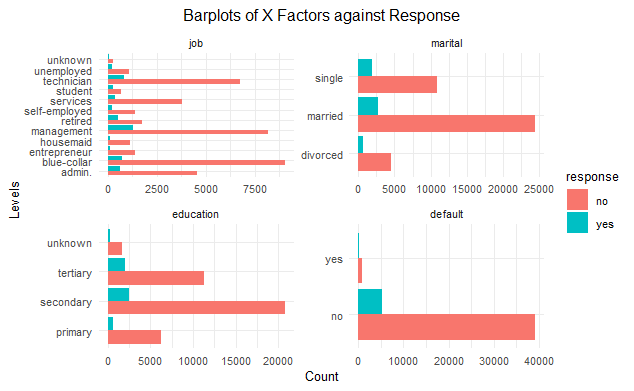

```r
bankCat1 = bankCat[, response := bankData$response]
# plot the distribution using violin and boxplots
# Grouped bar chart relationship between job and marital status
bankCat2 = bankCat1[,c("job", "marital", "education", "default", "response")]
ggplot(melt(bankCat2, id.vars="response"),
       aes(y = value,
           fill = response)) +
  facet_wrap(~ variable, scales = "free", ncol=2) +
  geom_bar(position = "dodge") +
  theme_minimal()+
  labs(x = "Count", y = "Levels", title = "Barplots of X Factors against Response")+
  theme(plot.title = element_text(hjust = 0.5))+
  theme(text = element_text(size=10))
```

```
attributes are not identical across measure variables; they will be dropped
```

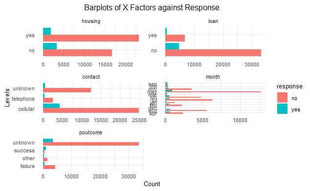

```r
bankCat3 = bankCat1[,c("housing", "loan", "contact", "month","poutcome", "response")]
ggplot(melt(bankCat3, id.vars="response"),
       aes(y = value,
           fill = response)) +
  facet_wrap(~ variable, scales = "free", ncol=2) +
  geom_bar(position = "dodge") +
  theme_minimal()+
  labs(x = "Count", y = "Levels", title = "Barplots of X Factors against Response")+
  theme(plot.title = element_text(hjust = 0.5))+
  theme(text = element_text(size=10))
```

```
attributes are not identical across measure variables; they will be dropped
```

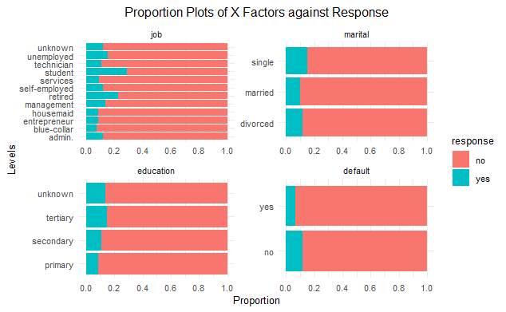

```r
ggplot(melt(bankCat2, id.vars="response"),
       aes(y = value,
           fill = response)) +
  facet_wrap(~ variable, scales = "free", ncol=2) +
  geom_bar(position = "fill") +
  scale_x_continuous(breaks = seq(0, 1, .2)) +
  theme_minimal()+
  theme(text = element_text(size=10))+
  labs(x = "Proportion", y = "Levels", title = "Proportion Plots of X Factors against Response")+
  theme(plot.title = element_text(hjust = 0.5))
```

```
attributes are not identical across measure variables; they will be dropped
```

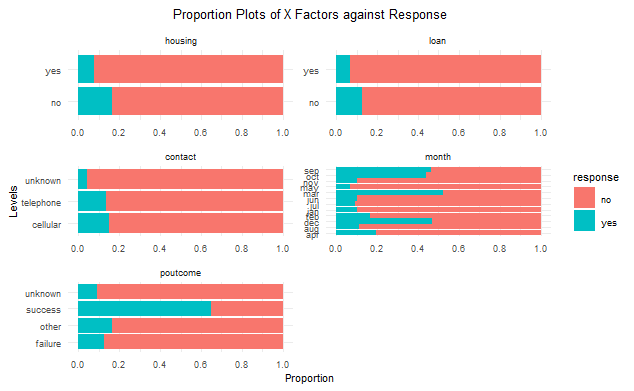

```r
ggplot(melt(bankCat3, id.vars="response"),
       aes(y = value,
           fill = response)) +
  facet_wrap(~ variable, scales = "free", ncol=2) +
  geom_bar(position = "fill") +
  scale_x_continuous(breaks = seq(0, 1, .2)) +
  theme_minimal()+
  theme(text = element_text(size=8))+
  labs(x = "Proportion", y = "Levels", title = "Proportion Plots of X Factors against Response")+
  theme(plot.title = element_text(hjust = 0.5))
```

## Data visualisations on customer data

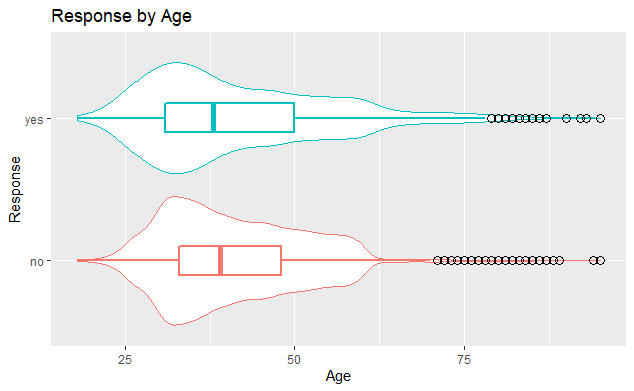

```r
# plot the distribution of age
ggplot(bankNum1,
       aes(x = response,
           y = age,
           color = response)) +
  geom_violin() +
  geom_boxplot(size=1,
               width = .2,
               outlier.shape = 1,
               outlier.color = "black",
               outlier.size  = 3) +
  scale_y_continuous() +
  labs(title = "Response by Age",
       x = "Response",
       y = "Age") +
  theme(legend.position = "none") +
  coord_flip()
```

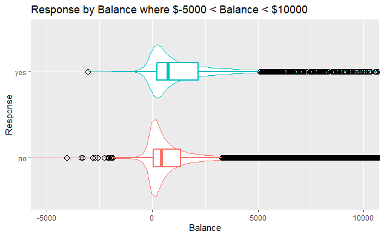

```r
ggplot(bankNum1,
       aes(y = response,
           x = balance,
           color = response)) +
  geom_violin() +
  geom_boxplot(size=1,
               width = .2,
               outlier.shape = 1,
               outlier.color = "black",
               outlier.size  = 3) +
  labs(title = "Response by Balance where $-5000 < Balance < $10000",
       y = "Response",
       x = "Balance") +
  theme(legend.position = "none") +
coord_cartesian(xlim = c(-5000, 10000))
```

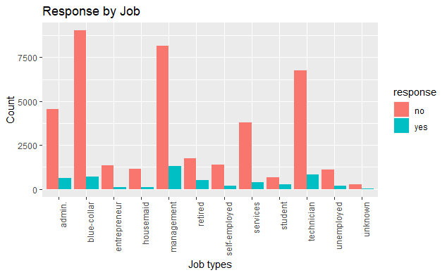

```r
# grouped bar chart
ggplot(data = bankData, aes(x = job,fill = response)) + geom_bar(position = "dodge")  +
  theme(axis.text.x = element_text(angle = 90, hjust = 1)) +
  labs(y = "Count", x = "Job types", title = "Response by Job")
```

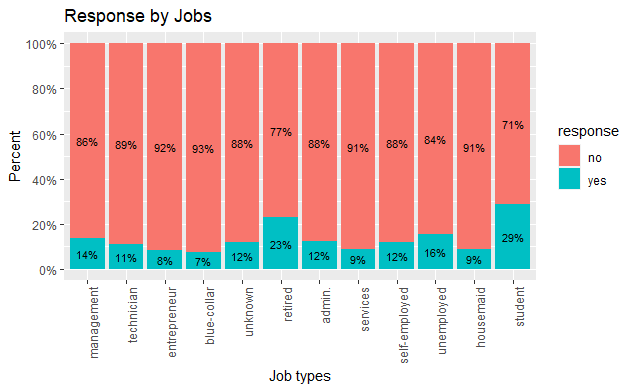

```r
# stacked bar chart with percentages
plotdata <- bankData %>%
  group_by(job, response) %>%
  summarize(n = n()) %>%
  mutate(pct = n/sum(n),
         lbl = scales::percent(pct))
ggplot(plotdata,
       aes(x= factor(job,
                      levels = unique(bankData$job)),
           y = pct,
           fill = factor(response,
                         levels = c("no", "yes"),
                         labels = c("no", "yes")))) +
  geom_bar(stat = "identity",
           position = "fill") +
  scale_y_continuous(breaks = seq(0, 1, .2),
                     label = percent) +
  geom_text(aes(label = lbl),
            size = 3,
            position = position_stack(vjust = 0.5)) +
  labs(x = "Job types", y = "Percent", title = "Response by Jobs", fill="response")+
  theme(axis.text.x = element_text(angle = 90, hjust = 1))
```

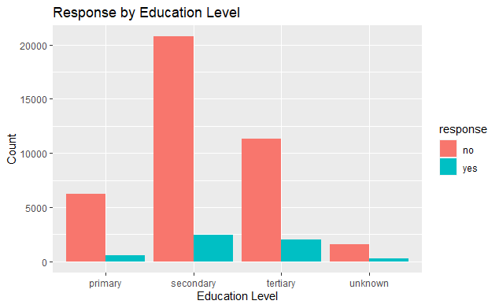

```r
# grouped bar chart
ggplot(data = bankData, aes(x = education,fill = response)) + geom_bar(position = "dodge")  +
  theme() +
  labs(y = "Count", x = "Education Level", title = "Response by Education Level")
```

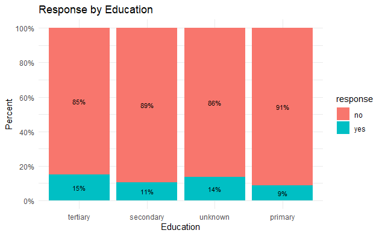

```r
# stacked bar chart with percentages
plotdata <- bankData %>%
  group_by(education, response) %>%
  summarize(n = n()) %>%
  mutate(pct = n/sum(n),
         lbl = scales::percent(pct))
ggplot(plotdata,
       aes(x= factor(education,
                      levels = unique(bankData$education)),
           y = pct,
           fill = factor(response,
                         levels = c("no", "yes"),
                         labels = c("no", "yes")))) +
  geom_bar(stat = "identity",
           position = "fill") +
  scale_y_continuous(breaks = seq(0, 1, .2),
                     label = percent) +
  geom_text(aes(label = lbl),
            size = 3,
            position = position_stack(vjust = 0.5)) +
  labs(x = "Education", y = "Percent", title = "Response by Education", fill="response")+
  theme_minimal()
```

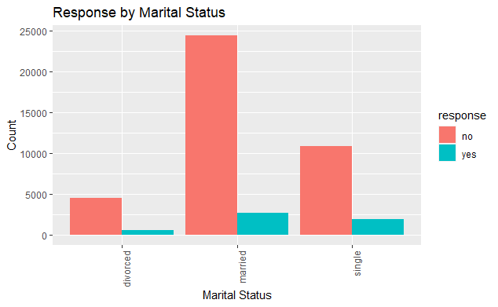

```r
# grouped bar chart
ggplot(data = bankData, aes(x = marital,fill = response)) + geom_bar(position = "dodge")  +
  theme(axis.text.x = element_text(angle = 90, hjust = 1)) +
  labs(y = "Count", x = "Marital Status", title = "Response by Marital Status")
```

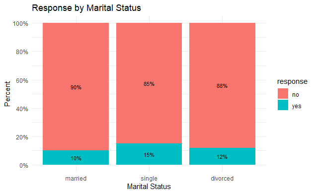

```r
# stacked bar chart with percentages
plotdata <- bankData %>%
  group_by(marital, response) %>%
  summarize(n = n()) %>%
  mutate(pct = n/sum(n),
         lbl = scales::percent(pct))
ggplot(plotdata,
       aes(x = factor(marital,
                      levels = unique(bankData$marital)),
           y = pct,
           fill = factor(response,
                         levels = c("no", "yes"),
                         labels = c("no", "yes")))) +
  geom_bar(stat = "identity",
           position = "fill") +
  scale_y_continuous(breaks = seq(0, 1, .2),
                     label = percent) +
  geom_text(aes(label = lbl),
            size = 3,
            position = position_stack(vjust = 0.5)) +
  labs(x = "Marital Status", y = "Percent", title = "Response by Marital Status", fill="response")+
  theme_minimal()
```

## Data Visualisations on telemarketing data

Duration

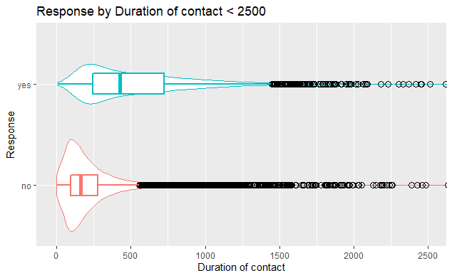

```r
ggplot(bankNum1,
       aes(y = response,
           x = duration,
           color = response)) +
  geom_violin() +
  geom_boxplot(size=1,
               width = .2,
               outlier.shape = 1,
               outlier.color = "black",
               outlier.size  = 3) +
  labs(title = "Response by Duration of contact < 2500",
       y = "Response",
       x = "Duration of contact") +
  theme(legend.position = "none") +
  coord_cartesian(xlim = c(-10, 2500))
```

```r
NA
```

Pdays

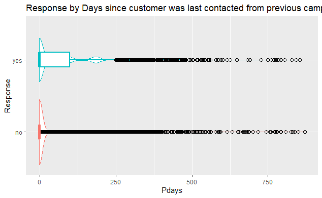

```r
# plot the distribution of pdays
ggplot(bankNum1,
       aes(x = response,
           y = pdays,
           color = response)) +
  geom_violin() +
  geom_boxplot(size=1,
               width = .2,
               outlier.shape = 1,
               outlier.color = "black",
               outlier.size  = 2) +
  scale_y_continuous() +
  labs(title = "Response by Days since customer was last contacted from previous campaign",
       x = "Response",
       y = "Pdays") +
  theme(legend.position = "none") +
  coord_flip()
```

Campaign

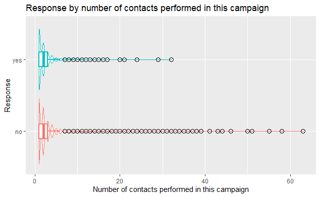

```r
# plot the distribution of age
ggplot(bankNum1,
       aes(x = response,
           y = campaign,
           color = response)) +
  geom_violin() +
  geom_boxplot(size=1,
               width = .2,
               outlier.shape = 1,
               outlier.color = "black",
               outlier.size  = 3) +
  #geom_jitter(alpha = 0.5,
  #            width=.2) +
  scale_y_continuous() +
  labs(title = "Response by number of contacts performed in this campaign",
       x = "Response",
       y = "Number of contacts performed in this campaign") +

  theme(legend.position = "none") +
  coord_flip()
```

Contact

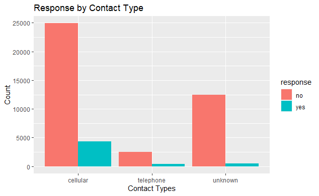

```r
# grouped bar chart
ggplot(data = bankData, aes(x = contact,fill = response)) + geom_bar(position = "dodge")  +
  theme() +
  labs(y = "Count", x = "Contact Types", title = "Response by Contact Type")
```

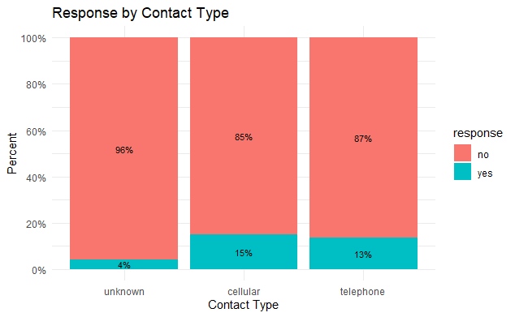

```r
# stacked bar chart with percentages
plotdata <- bankData %>%
  group_by(contact, response) %>%
  summarize(n = n()) %>%
  mutate(pct = n/sum(n),
         lbl = scales::percent(pct))
ggplot(plotdata,
       aes(x = factor(contact,
                      levels = unique(bankData$contact)),
           y = pct,
           fill = factor(response,
                         levels = c("no", "yes"),
                         labels = c("no", "yes")))) +
  geom_bar(stat = "identity",
           position = "fill") +
  scale_y_continuous(breaks = seq(0, 1, .2),
                     label = percent) +
  geom_text(aes(label = lbl),
            size = 3,
            position = position_stack(vjust = 0.5)) +
  labs(x = "Contact Type", y = "Percent", title = "Response by Contact Type", fill="response")+
  theme_minimal()
```

Poutcome

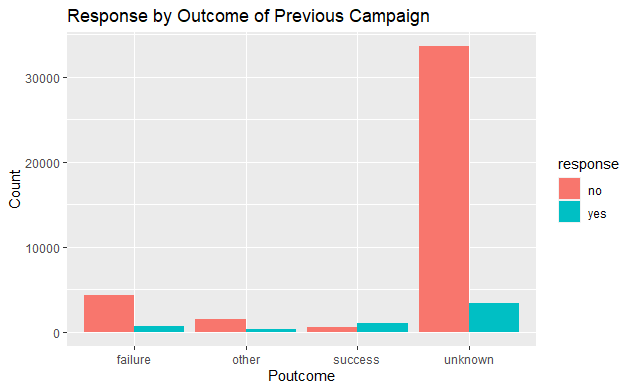

```r
# grouped bar chart
ggplot(data = bankData, aes(x = poutcome,fill = response)) + geom_bar(position = "dodge")  +
  theme() +
  labs(y = "Count", x = "Poutcome", title = "Response by Outcome of Previous Campaign")
```

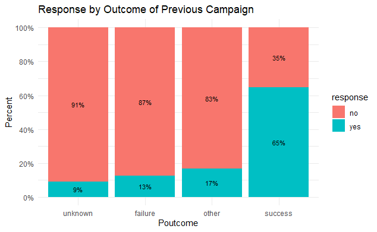

```r
# stacked bar chart with percentages
plotdata <- bankData %>%
  group_by(poutcome, response) %>%
  summarize(n = n()) %>%
  mutate(pct = n/sum(n),
         lbl = scales::percent(pct))
ggplot(plotdata,
       aes(x = factor(poutcome,
                      levels = unique(bankData$poutcome)),
           y = pct,
           fill = factor(response,
                         levels = c("no", "yes"),
                         labels = c("no", "yes")))) +
  geom_bar(stat = "identity",
           position = "fill") +
  scale_y_continuous(breaks = seq(0, 1, .2),
                     label = percent) +
  geom_text(aes(label = lbl),
            size = 3,
            position = position_stack(vjust = 0.5)) +
  labs(x = "Poutcome", y = "Percent", title = "Response by Outcome of Previous Campaign", fill="response")+
  theme_minimal()
```

### Correlation plot for numeric variables

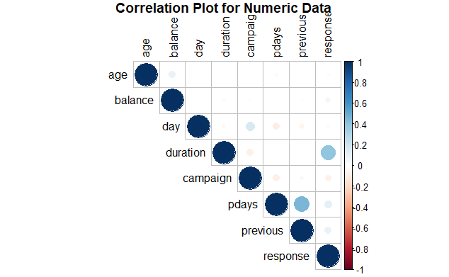

```r
corrData <- copy(bankData)
corrData$response <- as.numeric(factor(corrData$response, levels = c("no", "yes"), exclude = NULL))
# Correlation Matrix
bankNum = corrData[, lapply(corrData, is.numeric) == TRUE, with = FALSE, ]
corrplot(cor(bankNum), type = "upper", title = "Correlation Plot for Numeric Data", mar=c(0,0,1,0),
         tl.cex=1,
         tl.col = "black")
```

## Data Cleaning

```r
newData = copy(bankData)
numCol <- unlist(lapply(newData, is.numeric))
newData <- newData[ , numCol, with=FALSE]
newData$ID <- seq.int(nrow(newData)) # create id
```

### Removing outliers for numeric variables duration and campaign

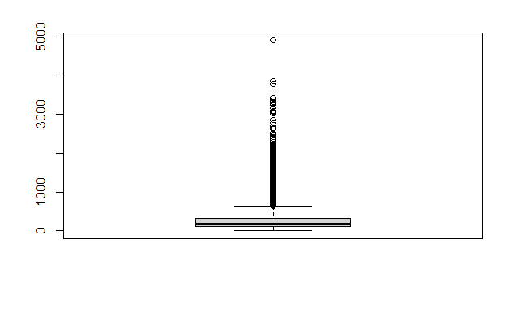

```r
# identify and removing outliers for Duration using boxplot
outliersDur<-boxplot(newData$duration)$out
```

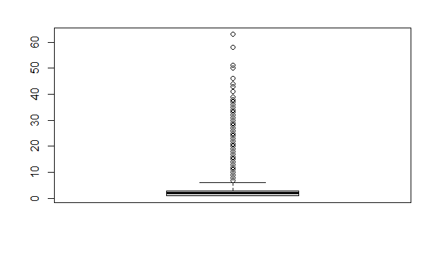

```r
newData<- newData[-which(newData$duration %in% outliersDur),]
# identify and removing outliers for Campaign using boxplot
outliersCam<-boxplot(newData$campaign)$out
```

```r
newData<- newData[-which(newData$campaign %in% outliersCam),]
```

```r
dim(newData)
```

```
[1] 39087     8
```

### Replace unknown with mode for categorical Variables job and education

```r
# create a copy
newCatTemp <- copy(bankData)
catCol <- which(sapply(bankData,is.factor))
newCat <- newCatTemp[ , catCol, with=FALSE]
newCat$ID <- seq.int(nrow(newCat))
```

```r
# find mode
getmode <- function(v) {
   uniqv <- unique(v)
   uniqv[which.max(tabulate(match(v, uniqv)))]
}

jobMode = getmode(newCat$job)
newCat$job[newCat$job == 'unknown'] <- jobMode

eduMode = getmode(newCat$education)
newCat[education=="unknown", education:=eduMode]
head(newCat)
```

| job | marital | education | default | housing | loan | contact | month | poutcome | response | ID |
| --- | --- | --- | --- | --- | --- | --- | --- | --- | --- | --- |
| management | married | tertiary | no | yes | no | unknown | may | unknown | no | 1 |
| technician | single | secondary | no | yes | no | unknown | may | unknown | no | 2 |
| entrepreneur | married | secondary | no | yes | yes | unknown | may | unknown | no | 3 |
| blue-collar | married | secondary | no | yes | no | unknown | may | unknown | no | 4 |
| blue-collar | single | secondary | no | no | no | unknown | may | unknown | no | 5 |
| management | married | tertiary | no | yes | no | unknown | may | unknown | no | 6 |

## Categorical Encoding

### Ordinal encoding for education and month

```r
encode_ordinal <- function(x, order = unique(x)) {
  x <- as.numeric(factor(x, levels = order, exclude = NULL))
  x
}

newCat$encodedEdu = encode_ordinal(newCat$education, order = c("primary", "secondary", "tertiary"))
newCat$encodedMonth = encode_ordinal(newCat$month, order = c("jan", "feb", "mar", "apr", "may", "jun", "jul", "aug", "sep", "oct", "nov", "dec"))
head(newCat)
```

| job | marital | education | default | housing | loan | contact | month | poutcome | response | ID | encodedEdu | encodedMonth |
| --- | --- | --- | --- | --- | --- | --- | --- | --- | --- | --- | --- | --- |
| management | married | tertiary | no | yes | no | unknown | may | unknown | no | 1 | 3 | 5 |
| technician | single | secondary | no | yes | no | unknown | may | unknown | no | 2 | 2 | 5 |
| entrepreneur | married | secondary | no | yes | yes | unknown | may | unknown | no | 3 | 2 | 5 |
| blue-collar | married | secondary | no | yes | no | unknown | may | unknown | no | 4 | 2 | 5 |
| blue-collar | single | secondary | no | no | no | unknown | may | unknown | no | 5 | 2 | 5 |
| management | married | tertiary | no | yes | no | unknown | may | unknown | no | 6 | 3 | 5 |

### One-hot encoding

```r
newCat_OH = copy(newCat)
oneHot <- newCat_OH[, c("job","marital", "housing", "default", "loan", "contact", "poutcome")]
summary(oneHot)
```

```
          job            marital      housing     default      loan            contact         poutcome
 blue-collar:10020   divorced: 5207   no :20081   no :44396   no :37967   cellular :29285   failure: 4901
 management : 9458   married :27214   yes:25130   yes:  815   yes: 7244   telephone: 2906   other  : 1840
 technician : 7597   single  :12790                                       unknown  :13020   success: 1511
 admin.     : 5171                                                                          unknown:36959
 services   : 4154
 retired    : 2264
 (Other)    : 6547
```

```r
oneHot <- one_hot(as.data.table(oneHot))
oneHot$ID <- seq.int(nrow(oneHot))
head(oneHot)
```

| job_admin. | job_blue-collar | job_entrepreneur | job_housemaid | job_management | job_retired | job_self-employed | job_services | job_student | job_technician | job_unemployed | job_unknown | marital_divorced | marital_married | marital_single | housing_no | housing_yes | default_no | default_yes | loan_no | loan_yes | contact_cellular | contact_telephone | contact_unknown | poutcome_failure | poutcome_other | poutcome_success | poutcome_unknown | ID |
| --- | --- | --- | --- | --- | --- | --- | --- | --- | --- | --- | --- | --- | --- | --- | --- | --- | --- | --- | --- | --- | --- | --- | --- | --- | --- | --- | --- | --- |
| 0 | 0 | 0 | 0 | 1 | 0 | 0 | 0 | 0 | 0 | 0 | 0 | 0 | 1 | 0 | 0 | 1 | 1 | 0 | 1 | 0 | 0 | 0 | 1 | 0 | 0 | 0 | 1 | 1 |
| 0 | 0 | 0 | 0 | 0 | 0 | 0 | 0 | 0 | 1 | 0 | 0 | 0 | 0 | 1 | 0 | 1 | 1 | 0 | 1 | 0 | 0 | 0 | 1 | 0 | 0 | 0 | 1 | 2 |
| 0 | 0 | 1 | 0 | 0 | 0 | 0 | 0 | 0 | 0 | 0 | 0 | 0 | 1 | 0 | 0 | 1 | 1 | 0 | 0 | 1 | 0 | 0 | 1 | 0 | 0 | 0 | 1 | 3 |
| 0 | 1 | 0 | 0 | 0 | 0 | 0 | 0 | 0 | 0 | 0 | 0 | 0 | 1 | 0 | 0 | 1 | 1 | 0 | 1 | 0 | 0 | 0 | 1 | 0 | 0 | 0 | 1 | 4 |
| 0 | 1 | 0 | 0 | 0 | 0 | 0 | 0 | 0 | 0 | 0 | 0 | 0 | 0 | 1 | 1 | 0 | 1 | 0 | 1 | 0 | 0 | 0 | 1 | 0 | 0 | 0 | 1 | 5 |
| 0 | 0 | 0 | 0 | 1 | 0 | 0 | 0 | 0 | 0 | 0 | 0 | 0 | 1 | 0 | 0 | 1 | 1 | 0 | 1 | 0 | 0 | 0 | 1 | 0 | 0 | 0 | 1 | 6 |

## Final cleaned data (After Data Cleaning)

```r
finalData <- left_join(newData,newCat, by="ID")
finalData <- left_join(finalData, oneHot, by="ID")
finalData$response = as.numeric(ifelse(finalData$response=="yes", 1, 0))
# drop columns
finalData = finalData[,c("ID","job", "marital", "education", "default", "housing", "loan", "contact", "month", "poutcome", "pdays", "job_unknown"):= NULL]
head(finalData, 50)
```

| age | balance | day | duration | campaign | previous | response | encodedEdu | encodedMonth | job_admin. | job_blue-collar | job_entrepreneur | job_housemaid | job_management | job_retired | job_self-employed | job_services | job_student | job_technician | job_unemployed | marital_divorced | marital_married | marital_single | housing_no | housing_yes | default_no | default_yes | loan_no | loan_yes | contact_cellular | … |
| --- | --- | --- | --- | --- | --- | --- | --- | --- | --- | --- | --- | --- | --- | --- | --- | --- | --- | --- | --- | --- | --- | --- | --- | --- | --- | --- | --- | --- | --- | --- |
| 58 | 2143 | 5 | 261 | 1 | 0 | 0 | 3 | 5 | 0 | 0 | 0 | 0 | 1 | 0 | 0 | 0 | 0 | 0 | 0 | 0 | 1 | 0 | 0 | 1 | 1 | 0 | 1 | 0 | 0 | … |
| 44 | 29 | 5 | 151 | 1 | 0 | 0 | 2 | 5 | 0 | 0 | 0 | 0 | 0 | 0 | 0 | 0 | 0 | 1 | 0 | 0 | 0 | 1 | 0 | 1 | 1 | 0 | 1 | 0 | 0 | … |
| 33 | 2 | 5 | 76 | 1 | 0 | 0 | 2 | 5 | 0 | 0 | 1 | 0 | 0 | 0 | 0 | 0 | 0 | 0 | 0 | 0 | 1 | 0 | 0 | 1 | 1 | 0 | 0 | 1 | 0 | … |
| 47 | 1506 | 5 | 92 | 1 | 0 | 0 | 2 | 5 | 0 | 1 | 0 | 0 | 0 | 0 | 0 | 0 | 0 | 0 | 0 | 0 | 1 | 0 | 0 | 1 | 1 | 0 | 1 | 0 | 0 | … |
| 33 | 1 | 5 | 198 | 1 | 0 | 0 | 2 | 5 | 0 | 1 | 0 | 0 | 0 | 0 | 0 | 0 | 0 | 0 | 0 | 0 | 0 | 1 | 1 | 0 | 1 | 0 | 1 | 0 | 0 | … |
| 35 | 231 | 5 | 139 | 1 | 0 | 0 | 3 | 5 | 0 | 0 | 0 | 0 | 1 | 0 | 0 | 0 | 0 | 0 | 0 | 0 | 1 | 0 | 0 | 1 | 1 | 0 | 1 | 0 | 0 | … |
| 28 | 447 | 5 | 217 | 1 | 0 | 0 | 3 | 5 | 0 | 0 | 0 | 0 | 1 | 0 | 0 | 0 | 0 | 0 | 0 | 0 | 0 | 1 | 0 | 1 | 1 | 0 | 0 | 1 | 0 | … |
| 42 | 2 | 5 | 380 | 1 | 0 | 0 | 3 | 5 | 0 | 0 | 1 | 0 | 0 | 0 | 0 | 0 | 0 | 0 | 0 | 1 | 0 | 0 | 0 | 1 | 0 | 1 | 1 | 0 | 0 | … |
| 58 | 121 | 5 | 50 | 1 | 0 | 0 | 1 | 5 | 0 | 0 | 0 | 0 | 0 | 1 | 0 | 0 | 0 | 0 | 0 | 0 | 1 | 0 | 0 | 1 | 1 | 0 | 1 | 0 | 0 | … |
| 43 | 593 | 5 | 55 | 1 | 0 | 0 | 2 | 5 | 0 | 0 | 0 | 0 | 0 | 0 | 0 | 0 | 0 | 1 | 0 | 0 | 0 | 1 | 0 | 1 | 1 | 0 | 1 | 0 | 0 | … |

[output cut: 40 more lines]

```r
dim(finalData)
```

```
[1] 39087    36
```

```r
Filter(var, finalData) # drop columns with all same value
```

| age | balance | day | duration | campaign | previous | response | encodedEdu | encodedMonth | job_admin. | job_blue-collar | job_entrepreneur | job_housemaid | job_management | job_retired | job_self-employed | job_services | job_student | job_technician | job_unemployed | marital_divorced | marital_married | marital_single | housing_no | housing_yes | default_no | default_yes | loan_no | loan_yes | contact_cellular | … |
| --- | --- | --- | --- | --- | --- | --- | --- | --- | --- | --- | --- | --- | --- | --- | --- | --- | --- | --- | --- | --- | --- | --- | --- | --- | --- | --- | --- | --- | --- | --- |
| 58 | 2143 | 5 | 261 | 1 | 0 | 0 | 3 | 5 | 0 | 0 | 0 | 0 | 1 | 0 | 0 | 0 | 0 | 0 | 0 | 0 | 1 | 0 | 0 | 1 | 1 | 0 | 1 | 0 | 0 | … |
| 44 | 29 | 5 | 151 | 1 | 0 | 0 | 2 | 5 | 0 | 0 | 0 | 0 | 0 | 0 | 0 | 0 | 0 | 1 | 0 | 0 | 0 | 1 | 0 | 1 | 1 | 0 | 1 | 0 | 0 | … |
| 33 | 2 | 5 | 76 | 1 | 0 | 0 | 2 | 5 | 0 | 0 | 1 | 0 | 0 | 0 | 0 | 0 | 0 | 0 | 0 | 0 | 1 | 0 | 0 | 1 | 1 | 0 | 0 | 1 | 0 | … |
| 47 | 1506 | 5 | 92 | 1 | 0 | 0 | 2 | 5 | 0 | 1 | 0 | 0 | 0 | 0 | 0 | 0 | 0 | 0 | 0 | 0 | 1 | 0 | 0 | 1 | 1 | 0 | 1 | 0 | 0 | … |
| 33 | 1 | 5 | 198 | 1 | 0 | 0 | 2 | 5 | 0 | 1 | 0 | 0 | 0 | 0 | 0 | 0 | 0 | 0 | 0 | 0 | 0 | 1 | 1 | 0 | 1 | 0 | 1 | 0 | 0 | … |
| 35 | 231 | 5 | 139 | 1 | 0 | 0 | 3 | 5 | 0 | 0 | 0 | 0 | 1 | 0 | 0 | 0 | 0 | 0 | 0 | 0 | 1 | 0 | 0 | 1 | 1 | 0 | 1 | 0 | 0 | … |
| 28 | 447 | 5 | 217 | 1 | 0 | 0 | 3 | 5 | 0 | 0 | 0 | 0 | 1 | 0 | 0 | 0 | 0 | 0 | 0 | 0 | 0 | 1 | 0 | 1 | 1 | 0 | 0 | 1 | 0 | … |
| 42 | 2 | 5 | 380 | 1 | 0 | 0 | 3 | 5 | 0 | 0 | 1 | 0 | 0 | 0 | 0 | 0 | 0 | 0 | 0 | 1 | 0 | 0 | 0 | 1 | 0 | 1 | 1 | 0 | 0 | … |
| 58 | 121 | 5 | 50 | 1 | 0 | 0 | 1 | 5 | 0 | 0 | 0 | 0 | 0 | 1 | 0 | 0 | 0 | 0 | 0 | 0 | 1 | 0 | 0 | 1 | 1 | 0 | 1 | 0 | 0 | … |
| 43 | 593 | 5 | 55 | 1 | 0 | 0 | 2 | 5 | 0 | 0 | 0 | 0 | 0 | 0 | 0 | 0 | 0 | 1 | 0 | 0 | 0 | 1 | 0 | 1 | 1 | 0 | 1 | 0 | 0 | … |

[output cut: 990 more lines]

## More Data Visualisations on Cleaned Data

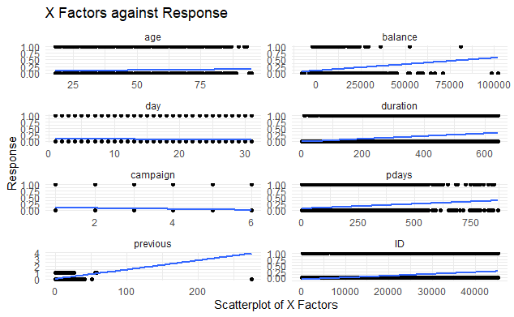

```r
newNum = copy(newData)
newNum1 = newNum[,response:=finalData$response]
# plot the distribution using violin and boxplots
ggplot(melt(newNum1, id.vars="response"),
       aes(x = value,
           y = response)) +
  facet_wrap(~ variable, scales = "free", ncol=2) +
  geom_point()+
  geom_smooth(method=lm, se=FALSE)+
  theme_minimal()+
  labs(x = "Scatterplot of X Factors", y = "Response", title = "X Factors against Response")
```

```r
newNum1$response = as.factor(newNum1$response)
levels(newNum1$response) <- c('no', 'yes')
```

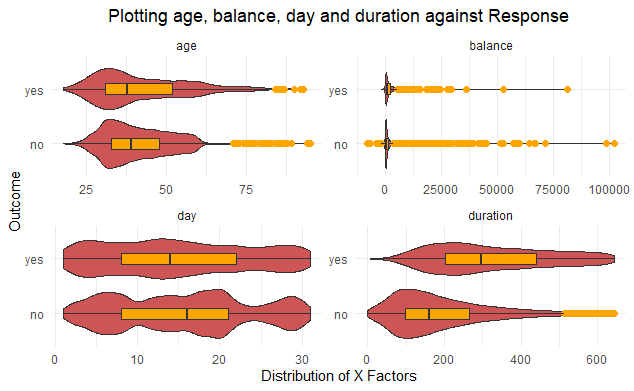

```r
# plot the distribution using violin and boxplots
newNum2 = newNum1[,c("age", "balance", "day", "duration", "response")]
ggplot(melt(newNum2, id.vars="response"),
       aes(x = value,
           y = response)) +
  facet_wrap(~ variable, scales = "free", ncol=2) +
  geom_violin(fill = "indianred3") +
  geom_boxplot(width = .2,
               fill = "orange",
               outlier.color = "orange",
               outlier.size = 2)+
  theme_minimal()+
  labs(x = "Distribution of X Factors", y = "Outcome", title = "Plotting age, balance, day and duration against Response") +
  theme(plot.title = element_text(hjust = 0.5))
```

```r
newNum1 = copy(newNum)
newNum1 = newNum1[,response:=finalData$response]
newNum1$response = as.factor(newNum1$response)
levels(newNum1$response) <- c('no', 'yes')
```

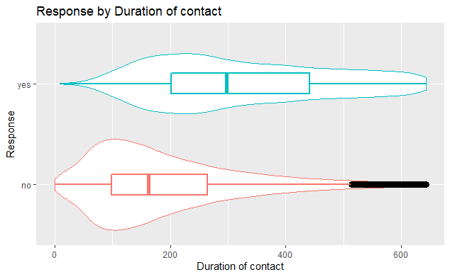

```r
# plot the distribution of duration
ggplot(newNum1,
       aes(x = response,
           y = duration,
           color = response)) +
  geom_violin() +
  geom_boxplot(size=1,
               width = .2,
               outlier.shape = 1,
               outlier.color = "black",
               outlier.size  = 3) +
  #geom_jitter(alpha = 0.5,
  #            width=.2) +
  scale_y_continuous() +
  labs(title = "Response by Duration of contact",
       x = "Response",
       y = "Duration of contact") +

  theme(legend.position = "none") +
  coord_flip()
```

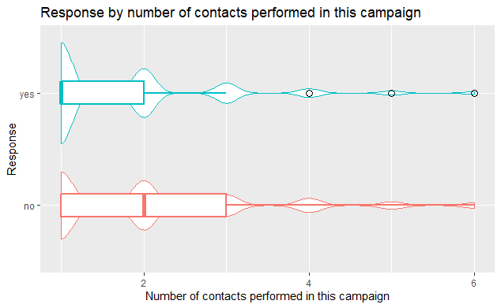

```r
# plot the distribution of campaign
ggplot(newNum1,
       aes(x = response,
           y = campaign,
           color = response)) +
  geom_violin() +
  geom_boxplot(size=1,
               width = .2,
               outlier.shape = 1,
               outlier.color = "black",
               outlier.size  = 3) +
  #geom_jitter(alpha = 0.5,
  #            width=.2) +
  scale_y_continuous() +
  labs(title = "Response by number of contacts performed in this campaign",
       x = "Response",
       y = "Number of contacts performed in this campaign") +

  theme(legend.position = "none") +
  coord_flip()
```

```r
newCat_VizTemp<- copy(newCat)
newCat_VizTemp<-newCat_VizTemp[newData$ID,]
newCat_Viz <- newCat_VizTemp[ , c("job", "marital", "education", "default", "housing", "loan", "contact", "month", "poutcome")]
```

```
attributes are not identical across measure variables; they will be dropped
```

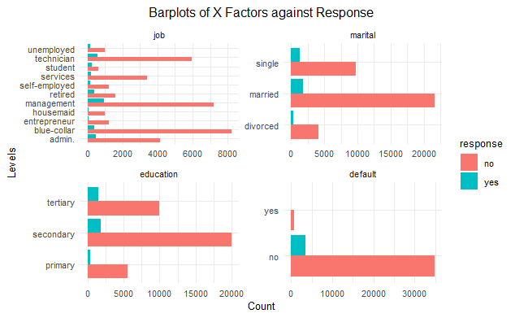

```r
newCat_Viz1 = newCat_Viz[, response:=finalData$response]
newCat_Viz1$response = as.factor(newNum1$response)
levels(newCat_Viz1$response) <- c('no', 'yes')
# plot the distribution using violin and boxplots
# Grouped bar chart relationship between job and marital status
newCat_Viz2 = newCat_Viz1[,c("job", "marital", "education", "default", "response")]
ggplot(melt(newCat_Viz2, id.vars="response"),
       aes(y = value,
           fill = response)) +
  facet_wrap(~ variable, scales = "free", ncol=2) +
  geom_bar(position = "dodge") +
  theme_minimal()+
  labs(x = "Count", y = "Levels", title = "Barplots of X Factors against Response")+
  theme(plot.title = element_text(hjust = 0.5))+
  theme(text = element_text(size=10))
```

```
attributes are not identical across measure variables; they will be dropped
```

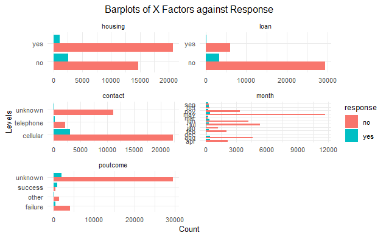

```r
newCat_Viz3 = newCat_Viz1[,c("housing", "loan", "contact", "month","poutcome", "response")]
ggplot(melt(newCat_Viz3, id.vars="response"),
       aes(y = value,
           fill = response)) +
  facet_wrap(~ variable, scales = "free", ncol=2) +
  geom_bar(position = "dodge") +
  theme_minimal()+
  labs(x = "Count", y = "Levels", title = "Barplots of X Factors against Response")+
  theme(plot.title = element_text(hjust = 0.5))+
  theme(text = element_text(size=10))
```

```
attributes are not identical across measure variables; they will be dropped
```

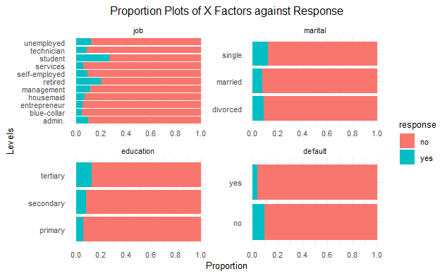

```r
ggplot(melt(newCat_Viz2, id.vars="response"),
       aes(y = value,
           fill = response)) +
  facet_wrap(~ variable, scales = "free", ncol=2) +
  geom_bar(position = "fill") +
  scale_x_continuous(breaks = seq(0, 1, .2)) +
  theme_minimal()+
  theme(text = element_text(size=10))+
  labs(x = "Proportion", y = "Levels", title = "Proportion Plots of X Factors against Response")+
  theme(plot.title = element_text(hjust = 0.5))
```

```
attributes are not identical across measure variables; they will be dropped
```

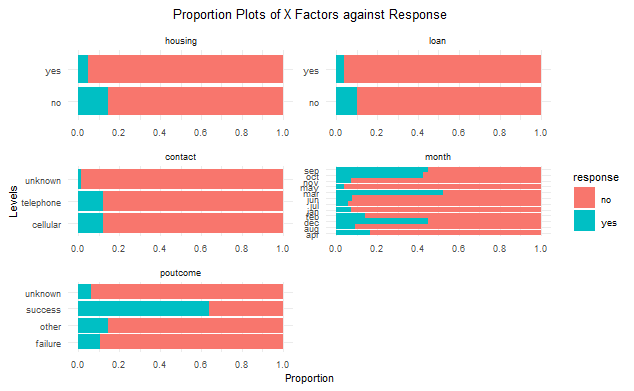

```r
ggplot(melt(newCat_Viz3, id.vars="response"),
       aes(y = value,
           fill = response)) +
  facet_wrap(~ variable, scales = "free", ncol=2) +
  geom_bar(position = "fill") +
  scale_x_continuous(breaks = seq(0, 1, .2)) +
  theme_minimal()+
  theme(text = element_text(size=8))+
  labs(x = "Proportion", y = "Levels", title = "Proportion Plots of X Factors against Response")+
  theme(plot.title = element_text(hjust = 0.5))
```

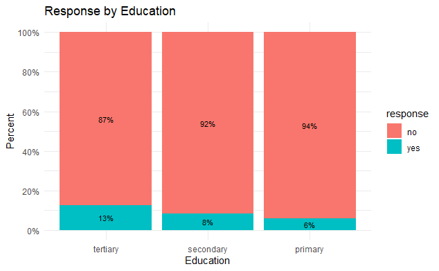

```r
# stacked bar chart with percentages
plotdata <- newCat_Viz2 %>%
  group_by(education, response) %>%
  summarize(n = n()) %>%
  mutate(pct = n/sum(n),
         lbl = scales::percent(pct))
ggplot(plotdata,
       aes(x= factor(education,
                      levels = unique(newCat_Viz2$education)),
           y = pct,
           fill = factor(response,
                         levels = c("no", "yes"),
                         labels = c("no", "yes")))) +
  geom_bar(stat = "identity",
           position = "fill") +
  scale_y_continuous(breaks = seq(0, 1, .2),
                     label = percent) +
  geom_text(aes(label = lbl),
            size = 3,
            position = position_stack(vjust = 0.5)) +
  labs(x = "Education", y = "Percent", title = "Response by Education", fill="response")+
  theme_minimal()
```

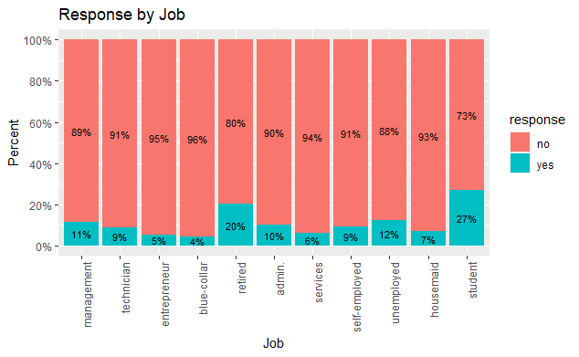

```r
# stacked bar chart with percentages
plotdata <- newCat_Viz2 %>%
  group_by(job, response) %>%
  summarize(n = n()) %>%
  mutate(pct = n/sum(n),
         lbl = scales::percent(pct))
ggplot(plotdata,
       aes(x= factor(job,
                      levels = unique(newCat_Viz2$job)),
           y = pct,
           fill = factor(response,
                         levels = c("no", "yes"),
                         labels = c("no", "yes")))) +
  geom_bar(stat = "identity",
           position = "fill") +
  scale_y_continuous(breaks = seq(0, 1, .2),
                     label = percent) +
  geom_text(aes(label = lbl),
            size = 3,
            position = position_stack(vjust = 0.5)) +
  labs(x = "Job", y = "Percent", title = "Response by Job", fill="response")+
  theme(axis.text.x = element_text(angle = 90, hjust = 1))
```

## Feature engineering using k means clustering

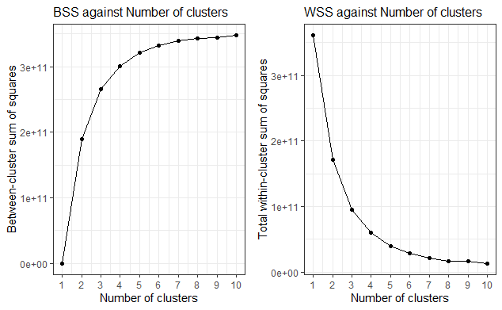

```r
# customer segmentation, clustering based on customer data
custData <- copy(finalData)
custData <- custData[, c("day", "duration", "campaign", "previous", "encodedMonth", "contact_unknown", "contact_cellular", "contact_telephone", "poutcome_failure", "poutcome_other", "poutcome_success", "poutcome_unknown"):=NULL]
bss <- numeric()
wss <- numeric()

# Run the algorithm for different values of k
set.seed(2004)

for(i in 1:10){

  # For each k, calculate betweenss and tot.withinss
  bss[i] <- kmeans(custData, centers=i)$betweenss
  wss[i] <- kmeans(custData, centers=i)$tot.withinss

}

# Between-cluster sum of squares vs Choice of k
p3 <- qplot(1:10, bss, geom=c("point", "line"),
            xlab="Number of clusters", ylab="Between-cluster sum of squares") +
  scale_x_continuous(breaks=seq(0, 10, 1)) +
  labs(title = "BSS against Number of clusters")+
  theme_bw()+
  theme(plot.title = element_text(size=12))

# Total within-cluster sum of squares vs Choice of k
p4 <- qplot(1:10, wss, geom=c("point", "line"),
            xlab="Number of clusters", ylab="Total within-cluster sum of squares") +
  scale_x_continuous(breaks=seq(0, 10, 1)) +
  labs(title = "WSS against Number of clusters")+
  theme_bw()+
  theme(plot.title = element_text(size=12))

# Subplot
grid.arrange(p3, p4, ncol=2)
```

Which is the optimal value for k? One should choose a number of clusters so that adding another cluster doesn’t give much better partition of the data. At some point the gain will drop, giving an angle in the graph (elbow criterion). The number of clusters is chosen at this point. In our case, it is clear that 4 is the appropriate value for k. k = 4 looks optimal

```r
# Execution of k-means with k=4
set.seed(2004)
bank_k4 <- kmeans(custData, centers=4)
# Cluster to which each point is allocated
bank_k4$centers
```

```
       age    balance   response encodedEdu job_admin. job_blue-collar job_entrepreneur job_housemaid
1 43.77698 14922.1626 0.13812950   2.378417 0.07913669      0.13812950       0.04460432    0.02877698
2 43.27895  4653.8643 0.13449817   2.195043 0.09894352      0.18508736       0.03047542    0.02681837
3 50.86667 47540.2222 0.08888889   2.533333 0.06666667      0.04444444       0.13333333    0.02222222
4 40.49373   521.4365 0.08376963   2.128168 0.12059835      0.22710546       0.03275991    0.02728497
  job_management job_retired job_self-employed job_services job_student job_technician job_unemployed
1      0.3467626  0.06187050        0.06330935   0.03884892  0.02158273     0.14676259     0.03021583
2      0.2602601  0.07822024        0.03535148   0.07090614  0.02275498     0.16030069     0.03088176
3      0.3333333  0.13333333        0.11111111   0.02222222  0.00000000     0.06666667     0.06666667
4      0.1975467  0.04631264        0.03359761   0.09639491  0.02166043     0.16858639     0.02815258
  marital_divorced marital_married marital_single housing_no housing_yes default_no  default_yes   loan_no
1       0.07625899       0.6661871      0.2575540  0.5640288   0.4359712  0.9985612 0.0014388489 0.9482014
2       0.10503860       0.6365299      0.2584315  0.5062983   0.4937017  0.9995937 0.0004063389 0.9051199
3       0.13333333       0.6888889      0.1777778  0.7777778   0.2222222  1.0000000 0.0000000000 0.9555556
4       0.11781601       0.5948542      0.2873298  0.4298280   0.5701720  0.9795064 0.0204936425 0.8274046
    loan_yes
1 0.05179856
2 0.09488013
3 0.04444444
4 0.17259536
```

```r
bank_k4$size
```

```
[1]   695  4922    45 33425
```

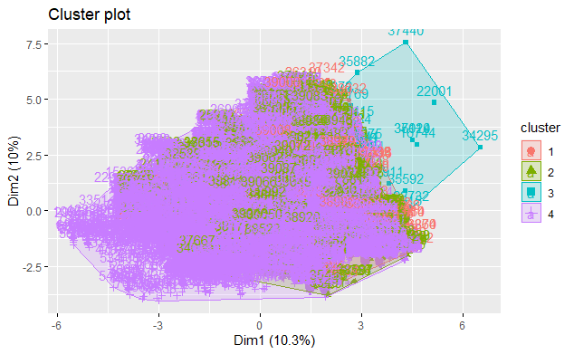

```r
fviz_cluster(bank_k4, data = custData)
```

```r
finalClusteredData = finalData[, cluster:=bank_k4$cluster ]
finalClusteredData$cluster = as.integer(finalClusteredData$cluster)
head(finalClusteredData)
```

| age | balance | day | duration | campaign | previous | response | encodedEdu | encodedMonth | job_admin. | job_blue-collar | job_entrepreneur | job_housemaid | job_management | job_retired | job_self-employed | job_services | job_student | job_technician | job_unemployed | marital_divorced | marital_married | marital_single | housing_no | housing_yes | default_no | default_yes | loan_no | loan_yes | contact_cellular | … |
| --- | --- | --- | --- | --- | --- | --- | --- | --- | --- | --- | --- | --- | --- | --- | --- | --- | --- | --- | --- | --- | --- | --- | --- | --- | --- | --- | --- | --- | --- | --- |
| 58 | 2143 | 5 | 261 | 1 | 0 | 0 | 3 | 5 | 0 | 0 | 0 | 0 | 1 | 0 | 0 | 0 | 0 | 0 | 0 | 0 | 1 | 0 | 0 | 1 | 1 | 0 | 1 | 0 | 0 | … |
| 44 | 29 | 5 | 151 | 1 | 0 | 0 | 2 | 5 | 0 | 0 | 0 | 0 | 0 | 0 | 0 | 0 | 0 | 1 | 0 | 0 | 0 | 1 | 0 | 1 | 1 | 0 | 1 | 0 | 0 | … |
| 33 | 2 | 5 | 76 | 1 | 0 | 0 | 2 | 5 | 0 | 0 | 1 | 0 | 0 | 0 | 0 | 0 | 0 | 0 | 0 | 0 | 1 | 0 | 0 | 1 | 1 | 0 | 0 | 1 | 0 | … |
| 47 | 1506 | 5 | 92 | 1 | 0 | 0 | 2 | 5 | 0 | 1 | 0 | 0 | 0 | 0 | 0 | 0 | 0 | 0 | 0 | 0 | 1 | 0 | 0 | 1 | 1 | 0 | 1 | 0 | 0 | … |
| 33 | 1 | 5 | 198 | 1 | 0 | 0 | 2 | 5 | 0 | 1 | 0 | 0 | 0 | 0 | 0 | 0 | 0 | 0 | 0 | 0 | 0 | 1 | 1 | 0 | 1 | 0 | 1 | 0 | 0 | … |
| 35 | 231 | 5 | 139 | 1 | 0 | 0 | 3 | 5 | 0 | 0 | 0 | 0 | 1 | 0 | 0 | 0 | 0 | 0 | 0 | 0 | 1 | 0 | 0 | 1 | 1 | 0 | 1 | 0 | 0 | … |

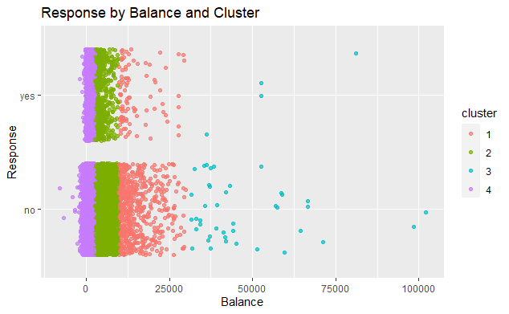

```r
finalClusteredData_Viz = copy(finalClusteredData)
finalClusteredData_Viz$cluster = as.factor(finalClusteredData_Viz$cluster)
finalClusteredData_Viz$response = as.factor(finalClusteredData_Viz$response)
levels(finalClusteredData_Viz$response) <- c('no', 'yes')
ggplot(finalClusteredData_Viz, aes(x = balance,
                     y = response,
                     color=cluster)) +
    geom_jitter(alpha = 0.7,
              size = 1.5) +
  labs(x = "Balance", y = "Response", title = "Response by Balance and Cluster")
```

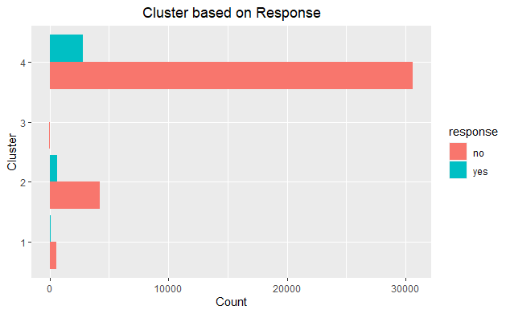

```r
# Grouped bar chart relationship between cluster and response
ggplot(finalClusteredData_Viz, aes(y = cluster, fill = response)) + geom_bar(position = "dodge") + theme()+
labs(y = "Cluster", x = "Count", title = "Cluster based on Response")+
theme(plot.title = element_text(hjust = 0.5))
```

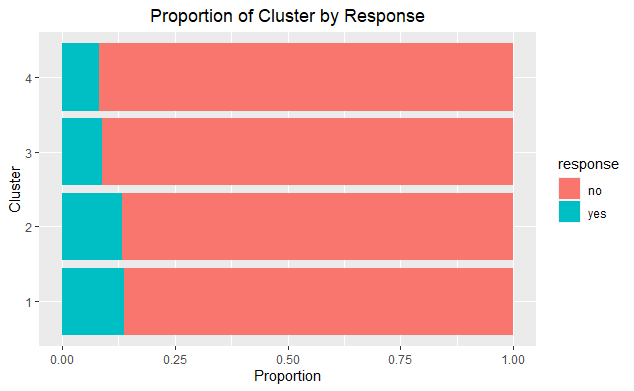

```r
# Stacked bar chart to show the praportion of individual based on marital status have a housing loan
ggplot(data = finalClusteredData_Viz, aes(y = cluster,fill = response)) + geom_bar(position = "fill") + labs(x = "Proportion", y = "Cluster", title = "Proportion of Cluster by Response")+
theme(plot.title = element_text(hjust = 0.5))
```

## Final Dataset

### Columns

```r
names(finalClusteredData)
```

```
 [1] "age"               "balance"           "day"               "duration"          "campaign"
 [6] "previous"          "response"          "encodedEdu"        "encodedMonth"      "job_admin."
[11] "job_blue-collar"   "job_entrepreneur"  "job_housemaid"     "job_management"    "job_retired"
[16] "job_self-employed" "job_services"      "job_student"       "job_technician"    "job_unemployed"
[21] "marital_divorced"  "marital_married"   "marital_single"    "housing_no"        "housing_yes"
[26] "default_no"        "default_yes"       "loan_no"           "loan_yes"          "contact_cellular"
[31] "contact_telephone" "contact_unknown"   "poutcome_failure"  "poutcome_other"    "poutcome_success"
[36] "poutcome_unknown"  "cluster"
```

### Correlation Matrix

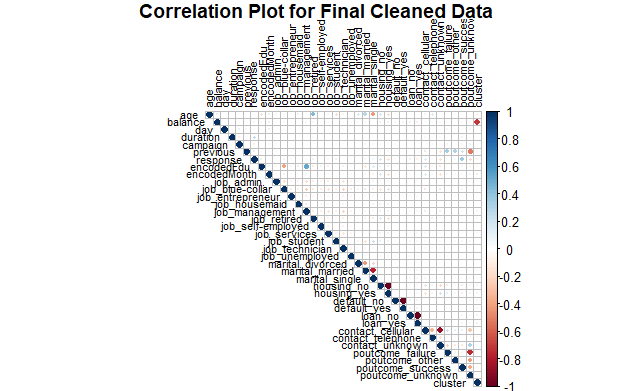

```r
corrplot(cor(finalClusteredData), type = "upper", title = "Correlation Plot for Final Cleaned Data", mar=c(0,0,1,0),
         tl.cex=0.7,
         tl.col = "black")
```

# Data Processing

## Train and Test Split

```r
# Generate a random number sequence that can be reproduced to verify results.
set.seed(2004)

train <- sample.split(Y = finalClusteredData$response, SplitRatio = 0.75)
trainset <- subset(finalClusteredData, train == T)
testset <- subset(finalClusteredData, train == F)
summary(trainset)
```

```
      age           balance            day           duration        campaign        previous
 Min.   :18.00   Min.   : -8019   Min.   : 1.00   Min.   :  0.0   Min.   :1.000   Min.   :  0.0000
 1st Qu.:33.00   1st Qu.:    71   1st Qu.: 8.00   1st Qu.:103.0   1st Qu.:1.000   1st Qu.:  0.0000
 Median :39.00   Median :   442   Median :16.00   Median :172.0   Median :2.000   Median :  0.0000
 Mean   :40.93   Mean   :  1328   Mean   :15.53   Mean   :208.9   Mean   :2.129   Mean   :  0.6026
 3rd Qu.:48.00   3rd Qu.:  1407   3rd Qu.:21.00   3rd Qu.:283.0   3rd Qu.:3.000   3rd Qu.:  0.0000
 Max.   :95.00   Max.   :102127   Max.   :31.00   Max.   :643.0   Max.   :6.000   Max.   :275.0000
    response         encodedEdu     encodedMonth      job_admin.    job_blue-collar  job_entrepreneur
 Min.   :0.00000   Min.   :1.000   Min.   : 1.000   Min.   :0.000   Min.   :0.0000   Min.   :0.00000
 1st Qu.:0.00000   1st Qu.:2.000   1st Qu.: 5.000   1st Qu.:0.000   1st Qu.:0.0000   1st Qu.:0.00000
 Median :0.00000   Median :2.000   Median : 6.000   Median :0.000   Median :0.0000   Median :0.00000
 Mean   :0.09114   Mean   :2.138   Mean   : 6.099   Mean   :0.118   Mean   :0.2213   Mean   :0.03142
 3rd Qu.:0.00000   3rd Qu.:3.000   3rd Qu.: 8.000   3rd Qu.:0.000   3rd Qu.:0.0000   3rd Qu.:0.00000
 Max.   :1.00000   Max.   :3.000   Max.   :12.000   Max.   :1.000   Max.   :1.0000   Max.   :1.00000
 job_housemaid     job_management   job_retired      job_self-employed  job_services    job_student
 Min.   :0.00000   Min.   :0.000   Min.   :0.00000   Min.   :0.00000   Min.   :0.000   Min.   :0.00000
 1st Qu.:0.00000   1st Qu.:0.000   1st Qu.:0.00000   1st Qu.:0.00000   1st Qu.:0.000   1st Qu.:0.00000
 Median :0.00000   Median :0.000   Median :0.00000   Median :0.00000   Median :0.000   Median :0.00000
 Mean   :0.02688   Mean   :0.207   Mean   :0.05065   Mean   :0.03466   Mean   :0.092   Mean   :0.02139
 3rd Qu.:0.00000   3rd Qu.:0.000   3rd Qu.:0.00000   3rd Qu.:0.00000   3rd Qu.:0.000   3rd Qu.:0.00000
 Max.   :1.00000   Max.   :1.000   Max.   :1.00000   Max.   :1.00000   Max.   :1.000   Max.   :1.00000
 job_technician   job_unemployed    marital_divorced marital_married  marital_single     housing_no
 Min.   :0.0000   Min.   :0.00000   Min.   :0.0000   Min.   :0.0000   Min.   :0.0000   Min.   :0.0000
 1st Qu.:0.0000   1st Qu.:0.00000   1st Qu.:0.0000   1st Qu.:0.0000   1st Qu.:0.0000   1st Qu.:0.0000
 Median :0.0000   Median :0.00000   Median :0.0000   Median :1.0000   Median :0.0000   Median :0.0000
 Mean   :0.1678   Mean   :0.02899   Mean   :0.1132   Mean   :0.6017   Mean   :0.2851   Mean   :0.4432
 3rd Qu.:0.0000   3rd Qu.:0.00000   3rd Qu.:0.0000   3rd Qu.:1.0000   3rd Qu.:1.0000   3rd Qu.:1.0000
 Max.   :1.0000   Max.   :1.00000   Max.   :1.0000   Max.   :1.0000   Max.   :1.0000   Max.   :1.0000
  housing_yes       default_no      default_yes         loan_no          loan_yes      contact_cellular
 Min.   :0.0000   Min.   :0.0000   Min.   :0.00000   Min.   :0.0000   Min.   :0.0000   Min.   :0.000
 1st Qu.:0.0000   1st Qu.:1.0000   1st Qu.:0.00000   1st Qu.:1.0000   1st Qu.:0.0000   1st Qu.:0.000
 Median :1.0000   Median :1.0000   Median :0.00000   Median :1.0000   Median :0.0000   Median :1.000
 Mean   :0.5568   Mean   :0.9825   Mean   :0.01753   Mean   :0.8386   Mean   :0.1614   Mean   :0.652
 3rd Qu.:1.0000   3rd Qu.:1.0000   3rd Qu.:0.00000   3rd Qu.:1.0000   3rd Qu.:0.0000   3rd Qu.:1.000
 Max.   :1.0000   Max.   :1.0000   Max.   :1.00000   Max.   :1.0000   Max.   :1.0000   Max.   :1.000
 contact_telephone contact_unknown  poutcome_failure poutcome_other    poutcome_success  poutcome_unknown
 Min.   :0.00000   Min.   :0.0000   Min.   :0.000    Min.   :0.00000   Min.   :0.00000   Min.   :0.0000
 1st Qu.:0.00000   1st Qu.:0.0000   1st Qu.:0.000    1st Qu.:0.00000   1st Qu.:0.00000   1st Qu.:1.0000
 Median :0.00000   Median :0.0000   Median :0.000    Median :0.00000   Median :0.00000   Median :1.0000
 Mean   :0.06184   Mean   :0.2862   Mean   :0.116    Mean   :0.04216   Mean   :0.03452   Mean   :0.8073
 3rd Qu.:0.00000   3rd Qu.:1.0000   3rd Qu.:0.000    3rd Qu.:0.00000   3rd Qu.:0.00000   3rd Qu.:1.0000
 Max.   :1.00000   Max.   :1.0000   Max.   :1.000    Max.   :1.00000   Max.   :1.00000   Max.   :1.0000
    cluster
 Min.   :1.000
 1st Qu.:4.000
 Median :4.000
 Mean   :3.698
 3rd Qu.:4.000
 Max.   :4.000
```

## Balance imbalanced dataset using SMOTE

```r
set.seed(2004)
# Count of unique value in the target variable
as.data.frame(table(trainset$response))
```

| Var1 | Freq |
| --- | --- |
| 0 | 26644 |
| 1 | 2672 |

```r
# Convert the response var from num to factor
trainset$response = as.factor(trainset$response)
## Smote : Synthetic Minority Oversampling Technique To Handle Response Imbalancy In Binary Classification
balanced_trainset = SMOTE(response~., trainset, perc.over = 200, k = 5, perc.under = 200, learner = NULL)

as.data.frame(table(balanced_trainset$response))
```

| Var1 | Freq |
| --- | --- |
| 0 | 10688 |
| 1 | 8016 |

```r
# Convert the response var from num to factor
testset$response = as.factor(testset$response)
## Smote : Synthetic Minority Oversampling Technique To Handle Response Imbalancy In Binary Classification
balanced_testset = SMOTE(response~., testset, perc.over = 200, k = 5, perc.under = 200, learner = NULL)

as.data.frame(table(balanced_testset$response))
```

| Var1 | Freq |
| --- | --- |
| 0 | 3560 |
| 1 | 2670 |

### Correlation Matrix after SMOTE

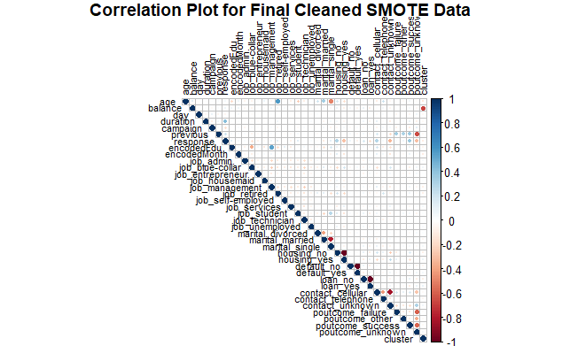

```r
SMOTEData = rbind(balanced_trainset, balanced_testset)
SMOTEData$response = as.integer(SMOTEData$response)
corrplot(cor(SMOTEData), type = "upper", title = "Correlation Plot for Final Cleaned SMOTE Data", mar=c(0,0,1,0),
         tl.cex=0.7,
         tl.col = "black")
```

# Machine Learning Models:

## Logistic Regression Model (All variables) with Stratified 10-fold Validation

```r
logistic = glm(response ~ .,
               data = balanced_trainset,
               family=binomial(link="logit"))

summary(logistic)
```

```
Call:
glm(formula = response ~ ., family = binomial(link = "logit"),
    data = balanced_trainset)

Deviance Residuals:
    Min       1Q   Median       3Q      Max
-3.3480  -0.6181  -0.2066   0.6401   2.9453

Coefficients: (7 not defined because of singularities)
                      Estimate Std. Error z value Pr(>|z|)
(Intercept)         -5.452e+00  3.299e-01 -16.527  < 2e-16 ***
age                  1.943e-03  2.526e-03   0.769 0.441641
balance             -6.793e-06  9.286e-06  -0.732 0.464456
day                 -7.433e-03  2.473e-03  -3.006 0.002648 **
duration             7.743e-03  1.530e-04  50.601  < 2e-16 ***
campaign            -2.996e-01  1.855e-02 -16.150  < 2e-16 ***
previous             4.209e-02  1.469e-02   2.866 0.004157 **
encodedEdu           4.826e-01  4.356e-02  11.078  < 2e-16 ***
encodedMonth        -3.753e-02  7.729e-03  -4.856 1.20e-06 ***
job_admin.           1.473e-01  1.228e-01   1.200 0.230173
`job_blue-collar`   -3.270e-01  1.219e-01  -2.684 0.007285 **
job_entrepreneur    -8.263e-01  1.757e-01  -4.702 2.57e-06 ***
job_housemaid       -2.760e-01  1.702e-01  -1.621 0.105003
job_management      -1.513e-01  1.211e-01  -1.250 0.211427
job_retired          5.567e-01  1.406e-01   3.960 7.49e-05 ***
`job_self-employed` -3.846e-01  1.571e-01  -2.448 0.014382 *
job_services        -3.504e-01  1.320e-01  -2.655 0.007931 **
job_student          9.571e-01  1.561e-01   6.130 8.77e-10 ***
job_technician      -2.167e-01  1.195e-01  -1.814 0.069727 .
job_unemployed              NA         NA      NA       NA
marital_divorced    -1.812e-01  7.756e-02  -2.337 0.019444 *
marital_married     -2.746e-01  5.245e-02  -5.235 1.65e-07 ***
marital_single              NA         NA      NA       NA
housing_no           1.053e+00  4.511e-02  23.336  < 2e-16 ***
housing_yes                 NA         NA      NA       NA
default_no           7.112e-01  2.049e-01   3.471 0.000518 ***
default_yes                 NA         NA      NA       NA
loan_no              1.011e+00  7.026e-02  14.383  < 2e-16 ***
loan_yes                    NA         NA      NA       NA
contact_cellular     1.754e+00  7.112e-02  24.666  < 2e-16 ***
contact_telephone    1.878e+00  1.032e-01  18.202  < 2e-16 ***
contact_unknown             NA         NA      NA       NA
poutcome_failure     2.582e-01  7.218e-02   3.577 0.000347 ***
poutcome_other       5.377e-01  1.026e-01   5.239 1.61e-07 ***
poutcome_success     2.919e+00  1.113e-01  26.218  < 2e-16 ***
poutcome_unknown            NA         NA      NA       NA
cluster             -2.336e-01  3.589e-02  -6.508 7.61e-11 ***
---
Signif. codes:  0 ‘***’ 0.001 ‘**’ 0.01 ‘*’ 0.05 ‘.’ 0.1 ‘ ’ 1

(Dispersion parameter for binomial family taken to be 1)

    Null deviance: 25546  on 18703  degrees of freedom
Residual deviance: 15351  on 18674  degrees of freedom
AIC: 15411

Number of Fisher Scoring iterations: 5
```

```r
probability = predict(logistic,type = 'response')
```

```r
folds=10
cvIndex <- createFolds(factor(balanced_trainset$response), folds, returnTrain = T) #stratified k fold
train_control <- trainControl(
  index = cvIndex,
  number = folds,
  method = "cv",
)

#install.packages('e1071', dependencies=TRUE)

logistic <- train(
  response~., data=balanced_trainset,
  trControl = train_control,
  method = "glm",
  family=binomial()
)
```

[output not shown]

```r
logistic.predict.train <- predict(logistic, newdata = balanced_trainset, type = "raw")
```

```
prediction from a rank-deficient fit may be misleading
```

```r
results <- data.frame(balanced_trainset, logistic.predict.train)
traintable <- table(logistic.predict.train, balanced_trainset$response)
traintable
```

```
logistic.predict.train    0    1
                     0 9085 1929
                     1 1603 6087
```

```r
round(prop.table(traintable),2)
```

```
logistic.predict.train    0    1
                     0 0.49 0.10
                     1 0.09 0.33
```

```r
print("Train Accuracy:")
```

```
[1] "Train Accuracy:"
```

```r
mean(results$logistic.predict.train == balanced_trainset$response)
```

```
[1] 0.8111634
```

```r
logistic.predict.test <- predict(logistic, newdata = balanced_testset, type = "raw")
```

```
prediction from a rank-deficient fit may be misleading
```

```r
results <- data.frame(balanced_testset, logistic.predict.test)
testtable <- table(logistic.predict.test, balanced_testset$response)
testtable
```

```
logistic.predict.test    0    1
                    0 3031  652
                    1  529 2018
```

```r
round(prop.table(testtable),2)
```

```
logistic.predict.test    0    1
                    0 0.49 0.10
                    1 0.08 0.32
```

```r
print("Test Accuracy:")
```

```
[1] "Test Accuracy:"
```

```r
mean(results$logistic.predict.test == balanced_testset$response)
```

```
[1] 0.8104334
```

## Logistic Regression (response ~ duration)

```r
logistic.2 = glm(response ~ duration,
               data = balanced_trainset,
               family=binomial)

summary(logistic.2)
prob = predict(logistic.2,type = 'response')
plot(x = balanced_trainset$duration, y = prob)
```

[output not shown]

```r
threshold = 0.5
# If probability greater than the threshold then predict y=1 or else y=0
y.hat = ifelse(prob>threshold, 1, 0)
# Create a confusion  matrix
table(balanced_trainset$response,y.hat,deparse.level = 2)
```

```
                          y.hat
balanced_trainset$response    0    1
                         0 8589 2099
                         1 3937 4079
```

```r
mean(y.hat == balanced_trainset$response)
```

```
[1] 0.6772883
```

## Logistic Regression (response ~ balance)

```r
logistic.2 = glm(response ~ balance,
               data = balanced_trainset,
               family=binomial)

summary(logistic.2)
```

```
Call:
glm(formula = response ~ balance, family = binomial, data = balanced_trainset)

Deviance Residuals:
   Min      1Q  Median      3Q     Max
-3.698  -1.032  -1.017   1.313   1.407

Coefficients:
              Estimate Std. Error z value Pr(>|z|)
(Intercept) -3.887e-01  1.711e-02  -22.72   <2e-16 ***
balance      7.075e-05  6.126e-06   11.55   <2e-16 ***
---
Signif. codes:  0 ‘***’ 0.001 ‘**’ 0.01 ‘*’ 0.05 ‘.’ 0.1 ‘ ’ 1

(Dispersion parameter for binomial family taken to be 1)

    Null deviance: 25546  on 18703  degrees of freedom
Residual deviance: 25388  on 18702  degrees of freedom
AIC: 25392

Number of Fisher Scoring iterations: 4
```

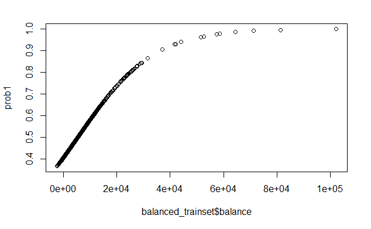

```r
prob1 = predict(logistic.2,type = 'response')
plot(x = balanced_trainset$balance, y = prob1)
```

```r
threshold = 0.5
# If probability greater than the threshold then predict y=1 or else y=0
y.hat1 = ifelse(prob1>threshold, 1, 0)
# Create a confusion  matrix
table(balanced_trainset$response,y.hat1,deparse.level = 2)
```

```
                          y.hat1
balanced_trainset$response     0     1
                         0 10177   511
                         1  7495   521
```

```r
mean(y.hat1 == balanced_trainset$response)
```

```
[1] 0.5719632
```

## Logistic Regression (response ~ campaign)

```r
logistic.3 = glm(response ~ campaign,
               data = balanced_trainset,
               family=binomial)

summary(logistic.3)
```

```
Call:
glm(formula = response ~ campaign, family = binomial, data = balanced_trainset)

Deviance Residuals:
    Min       1Q   Median       3Q      Max
-1.1805  -1.0503  -0.8142   1.1743   1.8720

Coefficients:
            Estimate Std. Error z value Pr(>|z|)
(Intercept)  0.32100    0.02954   10.87   <2e-16 ***
campaign    -0.31377    0.01355  -23.16   <2e-16 ***
---
Signif. codes:  0 ‘***’ 0.001 ‘**’ 0.01 ‘*’ 0.05 ‘.’ 0.1 ‘ ’ 1

(Dispersion parameter for binomial family taken to be 1)

    Null deviance: 25546  on 18703  degrees of freedom
Residual deviance: 24955  on 18702  degrees of freedom
AIC: 24959

Number of Fisher Scoring iterations: 4
```

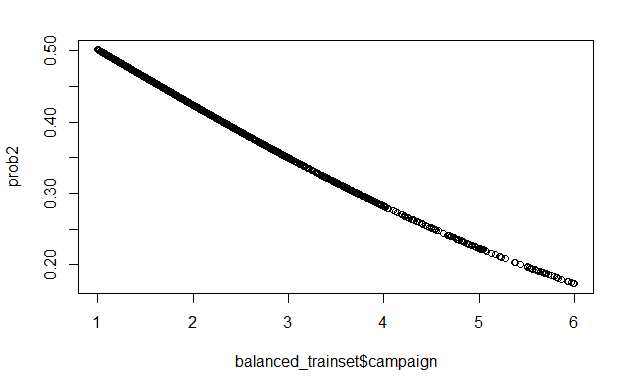

```r
prob2 = predict(logistic.3,type = 'response')
plot(x = balanced_trainset$campaign, y = prob2)
```

```r
threshold2 = 0.5
# If probability greater than the threshold then predict y=1 or else y=0
y.hat2 = ifelse(prob2>threshold2, 1, 0)
# Create a confusion  matrix
table(balanced_trainset$response,y.hat2,deparse.level = 2)
```

```
                          y.hat2
balanced_trainset$response    0    1
                         0 6408 4280
                         1 4562 3454
```

```r
mean(y.hat2 == balanced_trainset$response)
```

```
[1] 0.5272669
```